# PML - Predicting Exercise Classification

Cody Hollohan

4/5/2017

# Background

The purpose of this assignment is to have the student gain experience producing a classification model using their tool of choice. The [training](https://d396qusza40orc.cloudfront.net/predmachlearn/pml-training.csv) and [testing](https://d396qusza40orc.cloudfront.net/predmachlearn/pml-testing.csv) data to be used to train the model, and ultimately evaluate it, are generously provided by the contributors at http://groupware.les.inf.puc-rio.br/har.

This report elaborates on raw data manipulation prior to model selection, the model design, model validation, out of sample error considerations, model accuracy, and final results on the testing dataset.

# Partitioning Data into Training & Validation Subsets

Before any data manipulation, other than setting missing data to `NA`, we partition the training data into a 67% subset for training our model, and a 33% subset for validation. The testing dataset will only be used to evaluate the model as our final test for accuracy.

```r
# load packages
library(caret)
library(randomForest)
library(dplyr)

# Load data from url
train_raw <- data.frame(read.csv("http://d396qusza40orc.cloudfront.net/predmachlearn/pml-training.csv",
                                 na.strings = c("", "#DIV/0!")))

test_raw <- data.frame(read.csv("http://d396qusza40orc.cloudfront.net/predmachlearn/pml-testing.csv",
                                na.strings = c("", "#DIV/0!")))

# Index for training and validation set
tr_index <- createDataPartition(train_raw$classe, p = 0.667, list = FALSE)

# Split training data into "train_spl" & "validation_spl"
training_init <- train_raw[tr_index,-(1:7)]
validation_init <- train_raw[-tr_index,-(1:7)] # Leave for later...
```

# Raw Data Manipulation

Here, the strategy is to wittle down the amount of information fed into the model such that redundancy of computational operations and of correlated variables is minimized, an appropriate balance between bias and variance is produced, and only variables containing measurements on the data are included.

It is important to note that our selection of arguments to include in the `read.csv`function, such as `na.strings` or `stringsAsFactors`, affect the proceeding decisions making process. Consider if the that the string `c("","#DIV/0!")` is included in the argument `na.strings`, where we run into complications dealing with factor variables created of character variables, which actually contain numeric information. Here, the `NA` values within the factor variable columns are not detected by functions like `is.na`, which makes eliminating them a more manual process. Otherwise, however, if we set `stringsAsFactors = FALSE`, then the majority of this would-be factor data is coerced to `NA` as a result, and we don’t even get to take a look at what it may have contained.

The consequences of either choice are relatively irrelevant in this case, where the variation of the the observations of the specific variables in question is relatively low, making them likely candidates for removal prior to training the model, and the alternative results in the majority of the data of that variable to be coerced to `NA`, making it an equally likely candidate for removal prior to model training. The lesson here is that great care is to be taken when exploring datasets for their formatting nuances prior to (potentially shortsightedly) ruling out subsets of data.

```r
# Explore Training Data
dim(training_init)
```

```
## [1] 13090   153
```

```r
str(training_init)
```

```
## 'data.frame':    13090 obs. of  153 variables:
##  $ roll_belt               : num  1.41 1.41 1.42 1.48 1.42 1.42 1.43 1.45 1.45 1.42 ...
##  $ pitch_belt              : num  8.07 8.07 8.07 8.07 8.09 8.13 8.16 8.17 8.18 8.2 ...
##  $ yaw_belt                : num  -94.4 -94.4 -94.4 -94.4 -94.4 -94.4 -94.4 -94.4 -94.4 -94.4 ...
##  $ total_accel_belt        : int  3 3 3 3 3 3 3 3 3 3 ...
##  $ kurtosis_roll_belt      : num  NA NA NA NA NA NA NA NA NA NA ...
##  $ kurtosis_picth_belt     : num  NA NA NA NA NA NA NA NA NA NA ...
##  $ kurtosis_yaw_belt       : logi  NA NA NA NA NA NA ...
##  $ skewness_roll_belt      : num  NA NA NA NA NA NA NA NA NA NA ...
##  $ skewness_roll_belt.1    : num  NA NA NA NA NA NA NA NA NA NA ...
##  $ skewness_yaw_belt       : logi  NA NA NA NA NA NA ...
##  $ max_roll_belt           : Factor w/ 196 levels "-0.2","-0.4",..: 196 196 196 196 196 196 196 196 196 196 ...
##  $ max_picth_belt          : Factor w/ 23 levels "10","11","17",..: 23 23 23 23 23 23 23 23 23 23 ...
##  $ max_yaw_belt            : num  NA NA NA NA NA NA NA NA NA NA ...
##  $ min_roll_belt           : Factor w/ 185 levels "-0.2","-0.5",..: 185 185 185 185 185 185 185 185 185 185 ...
```

[output cut: 86 more lines]

We here remove `NA` data by considering both the factor variable `NA` data with basic logical expressions, as well as all of `NA` data with the `is.na` function. Some folks ran calculations on “near zero variation”, though this is unecessarily complicating the analysis, when in reality, only the missing or `NA` data is being removed (because of its lack of variance), though at the potential expense of computational demand.

Specifically, we remove variables having more than 90% `NA` data, though, strictly speaking, the data removed contained at least 93% `NA` values.

Note: All transformations performed on the training dataset are also performed on the validation dataset, such that our estimate of error is not affected some inconsistency between the two subsets of the raw “training” file.

```r
# Check for NA data
NA_vec <- sapply(training_init, function(i) sum(i == "NA" | is.na(i))/length(i) < 0.9)
NA_vec_val <- sapply(validation_init, function(j) sum(j == "NA" | is.na(j))/length(j) < 0.9)
# Subset on non-NA data
training <- training_init[,NA_vec]
validation <- validation_init[,NA_vec_val]

dim(training)
```

```
## [1] 13090    53
```

# Training Our Model With Cross-Validation Using The ‘Training’ Dataset and Random Forests

An overall seed is set to establish reproducibility in our methods, as well as between each of the 3 trial models that we are pitting against one another.

Out of curiosity, we explore the relative importance of each variable, such that the degree to which they contribute to classifying our target variable is quantified and ranked against the contributions of the other predictors.

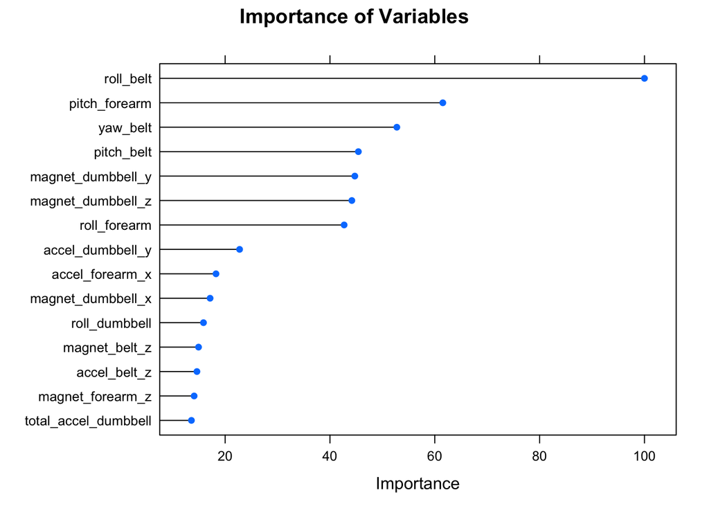

```r
# Traing model with 'randomForest' - 2 folds for cross validation
set.seed(2017)
control.fewer <- trainControl(method = 'cv', number = 2, verboseIter = FALSE)
mod.fewer <- train(classe ~ ., method = 'rf', data = training, trControl = control.fewer)
# Evaluate relative importance of each variable on classification of target variable
vimp.fewer <- varImp(mod.fewer)
plot(vimp.fewer, main = "Importance of Variables", top = 15)
```

```r
# Make prediction of classification
pred.fewer <- predict(mod.fewer, newdata = validation)
# Evaluate performance of model
confusionMatrix(validation$classe, pred.fewer)
```

```
## Confusion Matrix and Statistics
##
##           Reference
## Prediction    A    B    C    D    E
##          A 1853    3    0    0    2
##          B   14 1239   11    0    0
##          C    0    3 1129    7    0
##          D    0    0    8 1061    1
##          E    0    0    0    4 1197
##
## Overall Statistics
##
##                Accuracy : 0.9919
##                  95% CI : (0.9894, 0.9939)
##     No Information Rate : 0.2858
##     P-Value [Acc > NIR] : < 2.2e-16
##
##                   Kappa : 0.9897
##  Mcnemar's Test P-Value : NA
##
## Statistics by Class:
##
##                      Class: A Class: B Class: C Class: D Class: E
## Sensitivity            0.9925   0.9952   0.9834   0.9897   0.9975
## Specificity            0.9989   0.9953   0.9981   0.9984   0.9992
## Pos Pred Value         0.9973   0.9802   0.9912   0.9916   0.9967
## Neg Pred Value         0.9970   0.9989   0.9965   0.9980   0.9994
## Prevalence             0.2858   0.1906   0.1758   0.1641   0.1837
## Detection Rate         0.2837   0.1897   0.1728   0.1624   0.1833
## Detection Prevalence   0.2844   0.1935   0.1744   0.1638   0.1839
## Balanced Accuracy      0.9957   0.9952   0.9908   0.9940   0.9984
```

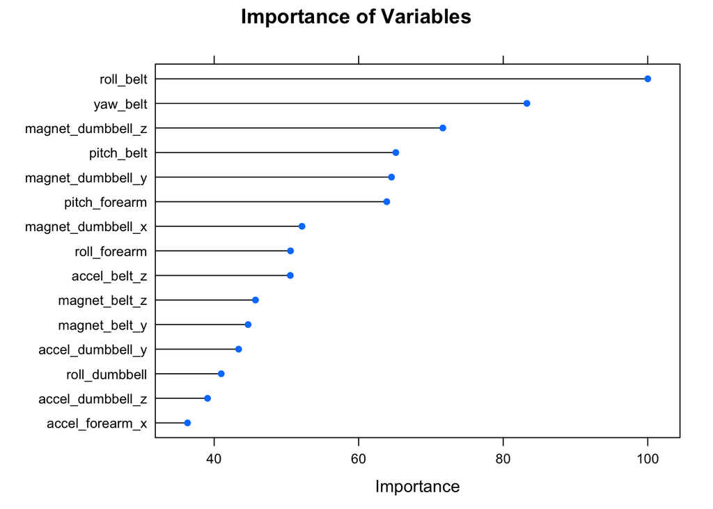

```r
# Train model with 'randomForest' - default cross validation settings
set.seed(2017)
control <- trainControl(method = 'cv', verboseIter = FALSE)
mod <- train(classe ~ ., method = 'rf', data = training, trControl = control)
# Evaluate relative importance of each variable on classification of target variable
vimp <- varImp(mod)
plot(vimp, main = "Importance of Variables", top = 15)
```